# Alternative analysis of postural sway data

This program runs some alternatives to the two-sample t-test. Consult the [data dictionary](https://github.com/pmean/data/blob/main/files/postural-sway.yaml) for information about the data itself.

This program was written by Steve Simon on 2024-10-13. It is placed in the public domain.

## Libraries

```r
library(tidyverse)
```

## Read data

```r
sway <- read_tsv(
  file="../data/postural-sway.txt",
  col_types="cnn")
names(sway) <- tolower(names(sway))
glimpse(sway)
```

```
Rows: 17
Columns: 3
$ age      <chr> "Elderly", "Elderly", "Elderly", "Elderly", "Elderly", "Elder…
$ fbsway   <dbl> 19, 30, 20, 19, 29, 25, 21, 24, 50, 25, 21, 17, 15, 14, 14, 2…
$ sidesway <dbl> 14, 41, 18, 11, 16, 24, 18, 21, 37, 17, 10, 16, 22, 12, 14, 1…
```

## Boxplot of front-to-back sway by age

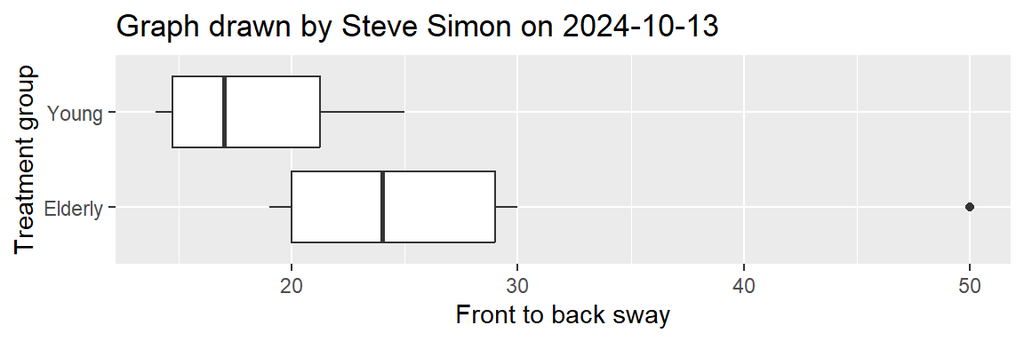

```r
sway |>
  ggplot(aes(age, fbsway)) +
    geom_boxplot() +
    ggtitle("Graph drawn by Steve Simon on 2024-10-13") +
    xlab("Treatment group") +
    ylab("Front to back sway") +
    coord_flip()
```

The outlier causes some concern about the validity of the two-sample t-test.

## Descriptive statistics for front-to-back sway by age

```r
sway |>
  group_by(age) |>
  summarize(
    fb_mn=mean(fbsway),
    fb_sd=sd(fbsway),
    n=n())
```

```
# A tibble: 2 × 4
  age     fb_mn fb_sd     n
  <chr>   <dbl> <dbl> <int>
1 Elderly  26.3  9.77     9
2 Young    18.1  4.09     8
```

In addition to the outlier, notice that the group with the larger mean (elderly) has the larger standard deviation. This indicates that a log transformation may produce better results.

## Log transformation, 1

```r
sway |>
  mutate(log_fbsway=log10(fbsway)) -> log_sway
```

## Log transformation, 2

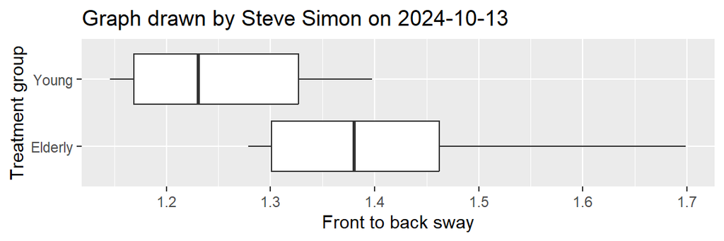

```r
log_sway |>
  ggplot(aes(age, log_fbsway)) +
    geom_boxplot() +
    ggtitle("Graph drawn by Steve Simon on 2024-10-13") +
    xlab("Treatment group") +
    ylab("Front to back sway") +
    coord_flip()
```

There are no outliers after a log transformation.

## Log transformation, 3

```r
log_sway |>
  group_by(age) |>
  summarize(
    log_mn=mean(log_fbsway),
    log_sd=sd(log_fbsway),
    n=n())
```

```
# A tibble: 2 × 4
  age     log_mn log_sd     n
  <chr>    <dbl>  <dbl> <int>
1 Elderly   1.40 0.135      9
2 Young     1.25 0.0952     8
```

The standard deviations on the log scale are quite a bit more similar than they were on the original scale.

## Two-sample t-test using the log transformation

```r
m2 <- t.test(
  log_fbsway ~ age,
  data=log_sway,
  alternative="two.sided",
  var.equal=TRUE)
m2
```

```
    Two Sample t-test

data:  log_fbsway by age
t = 2.6323, df = 15, p-value = 0.01884
alternative hypothesis: true difference in means between group Elderly and group Young is not equal to 0
95 percent confidence interval:
 0.02868192 0.27278285
sample estimates:
mean in group Elderly   mean in group Young
             1.399711              1.248978
```

There is a statistically significant difference between the log front-to-back sway between elderly patients and young patients. The confidence interval will be interpreted after transforming back to the original scale of measurement.

## Back-transform confidence interval to the original scale.

```r
10^(m2$conf.int)
```

```
[1] 1.068272 1.874057
attr(,"conf.level")
[1] 0.95
```

## Mann-Whitney-Wilcoxon

```r
wilcox.test(fbsway ~ age, data=sway)
```

```
    Wilcoxon rank sum test with continuity correction

data:  fbsway by age
W = 59, p-value = 0.02988
alternative hypothesis: true location shift is not equal to 0
```

Since the p-value is small, you would reject the null hypothesis and conclude that there is a statistically significant difference in front-to-back sway values between elderly and young patients.